# Final Project

Lishan Shi

## Overview

The project consists of five major parts: **introduction, exploratory data analysis, modeling, performance evaluation, and conclusion**. The introduction includes the basic strategy of modeling and some necessary information regarding the response variable. The EDA is divided into two subsections: data cleaning and data visualization. Importantly, **we did feature extraction by analyzing the covariance between variables** so we had a relatively small amount of predictors to work with in modeling. The process of modeling is fairly similar to what we did in the homework, so we will not repeat it here. In total, we fit six models: logistic regression, quadratic discriminant analysis, support vector machine with the radial kernel, classification tree, random forest, and boosted tree. For all three tree models, we did hyperparameter tuning and cross-validation. We evaluate the performance using accuracy and precision, **but precision is essentially more meaningful** since we have highly imbalanced data. The conclusion is a short summary of model performance and overall results but also includes my own perspective and experience when working on the project.

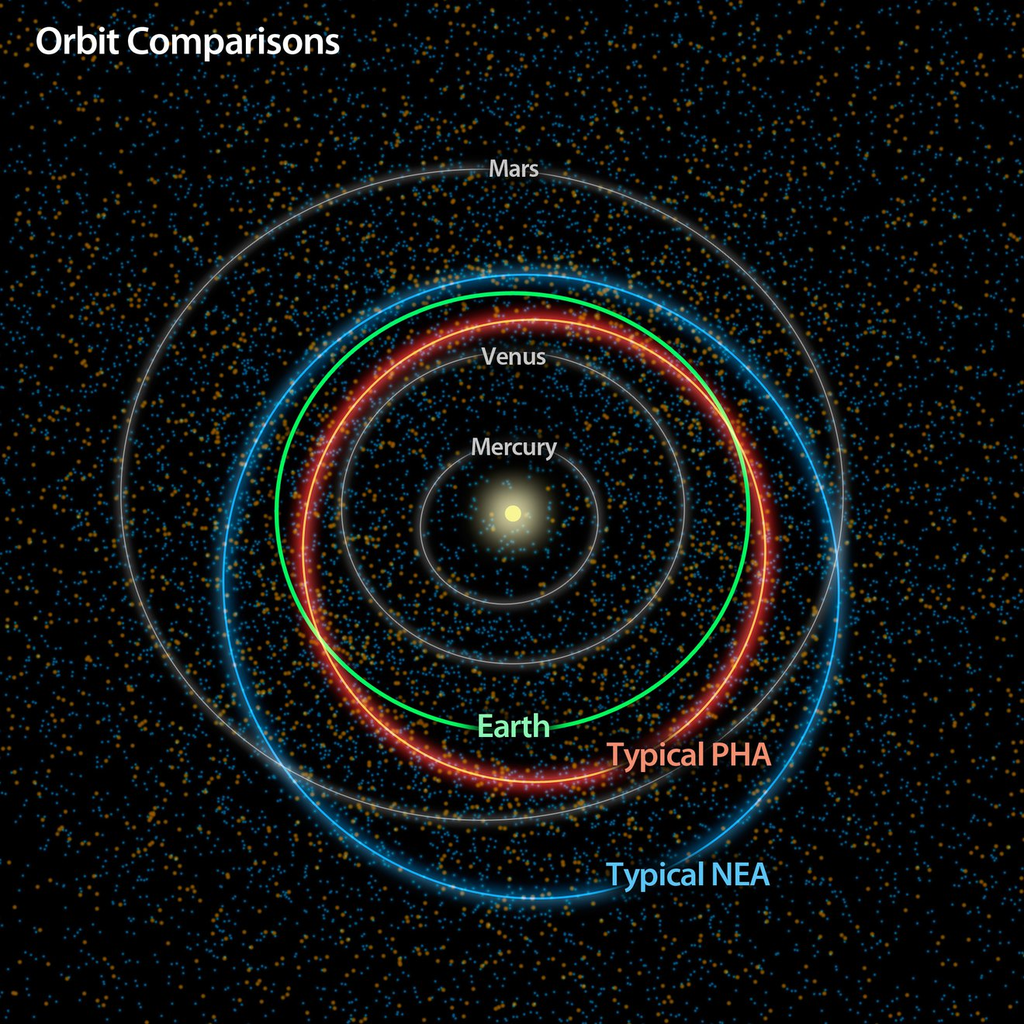

```r
knitr::include_graphics("C:/Users/lisha/Downloads/5.jpg")
```

# Introduction

The purpose of this project is to build a machine-learning model that **predicts whether or not an asteroid will be potentially hazardous to earth** using the predictors such as its absolute magnitude, estimated diameter, relative velocity, etc. The data is downloaded from Kaggle, but the original source is the Center for Near-Earth Object Studies at NASA, a department specifically for computing asteroid and comet orbits and their odds of Earth impact.

### Potentially hazardous object

Since we will be predicting whether an asteroid will be potentially hazardous or not, it is important to have some background information about it. **A potentially hazardous object (PHO) is a near-Earth object – either an asteroid or a comet – with an orbit that can make close approaches to the Earth and is large enough to cause significant regional damage in the event of an impact.** Though it seems to be scary, more than 99% of the known potentially hazardous objects would not be an impact threat over the next 100 years, if their orbits are reasonably well determined. The majority of these objects are potentially hazardous asteroids (PHA), while a few of them are comets. Though there are certain standards to determine whether an asteroid will be considered as PHA or not, it is beyond our consideration, as we are going to use given features from the data to predict the response. In other words, we do not want to know these standards beforehand such as which predictors are more important than others. Thus, our general assumption is that **we do not have any prior knowledge of PHA** except for some reasonable conjectures based on our elementary-level physics.

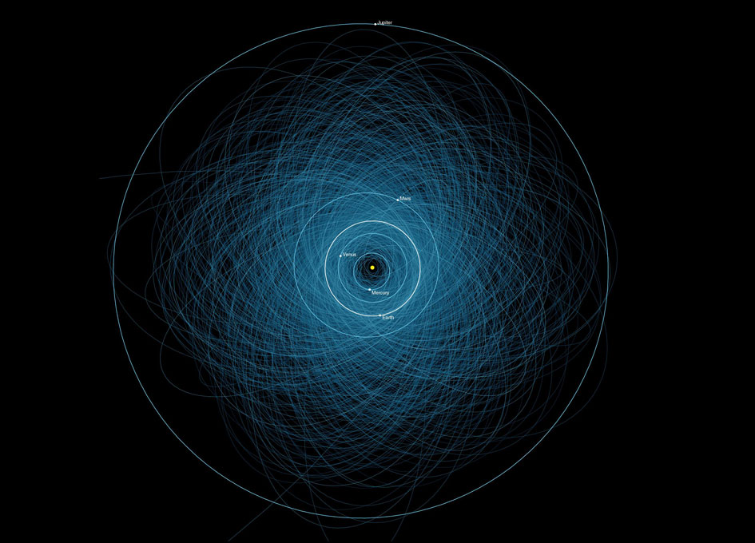

```r
knitr::include_graphics("C:/Users/lisha/Downloads/1.jpg")
```

### Why is this model relevant?

This model is important in the way that we could easily classify the objects to be PHA or not, using our information about these near-earth objects. According to NASA, there are over 30,000 near-earth asteroids, and it would be time-consuming to check more than 30 properties of each asteroid to determine if a given asteroid is PHA. For this reason, machine learning is an excellent approach to solving these kinds of problems, as algorithms tend to give quite accurate predictions in a relatively short amount of time.

# Exploratory Data Analysis

Before modeling, the first thing we should do is assessing our data. Our dataset contains over 4000 observations and 40 variables without any missing values. In this case, we do not need to deal with missing data. Rather, data cleaning for variables is necessary. **We will first tide and manipulate our data before creating any visualizations to explore some potential relationships between variables.** One clarification I want to make is that this data does not have its code book, so the variable name gives all the information.

### Loading Data and Packages

```r
knitr::opts_chunk$set(echo = TRUE, message = FALSE,
                      warning = FALSE, cache=TRUE)
```

```r
library(tidyverse) # loading packages
library(tidymodels)
library(janitor)
library(ggplot2)
library(rpart.plot)
library(randomForest)
library(vip)
library(ranger)
library(xgboost)
library(corrplot)
library(corrr)
library(ggcorrplot)
library(dplyr)
library(klaR)
tidymodels_prefer()
pho<-read.csv("C:/Users/lisha/Downloads/nasa.csv") # read the data
set.seed(403) # will be useful later in modelling
dim(pho) # 4687 40
```

```
## [1] 4687   40
```

```r
pho %>%
  head(1)
```

```
##   Neo.Reference.ID    Name Absolute.Magnitude Est.Dia.in.KM.min.
## 1          3703080 3703080               21.6          0.1272199
##   Est.Dia.in.KM.max. Est.Dia.in.M.min. Est.Dia.in.M.max. Est.Dia.in.Miles.min.
## 1          0.2844723          127.2199          284.4723            0.07905074
##   Est.Dia.in.Miles.max. Est.Dia.in.Feet.min. Est.Dia.in.Feet.max.
## 1             0.1767628             417.3881             933.3081
##   Close.Approach.Date Epoch.Date.Close.Approach Relative.Velocity.km.per.sec
## 1          1995-01-01              788947200000                     6.115834
##   Relative.Velocity.km.per.hr Miles.per.hour Miss.Dist..Astronomical.
## 1                       22017       13680.51                0.4194825
##   Miss.Dist..lunar. Miss.Dist..kilometers. Miss.Dist..miles. Orbiting.Body
## 1          163.1787               62753692          38993336         Earth
##   Orbit.ID Orbit.Determination.Date Orbit.Uncertainity
## 1       17      2017-04-06 08:36:37                  5
##   Minimum.Orbit.Intersection Jupiter.Tisserand.Invariant Epoch.Osculation
## 1                  0.0252819                       4.634          2458001
##   Eccentricity Semi.Major.Axis Inclination Asc.Node.Longitude Orbital.Period
## 1    0.4255491        1.407011    6.025981           314.3739       609.5998
##   Perihelion.Distance Perihelion.Arg Aphelion.Dist Perihelion.Time Mean.Anomaly
## 1           0.8082589       57.25747      2.005764         2458162     264.8375
##   Mean.Motion Equinox Hazardous
## 1   0.5905514   J2000      True
```

Our data contains 4687 observations and 40 variables.

### Data Cleaning

Since we have a huge number of variables in the dataset, we want to exclude some of them such as variables that measure the same parameters in different units, or variables that have little covariance with the output like the names of asteroids or id. Since all the asteroids orbit around earth, it is not necessary to include this information. For the same reason, we do not need to include equinox. Moreover, we should also clean the names of the variables to for later modeling.

```r
pho<-pho %>%
  clean_names() # clean the names of variables
pho<-pho%>%
  select(-est_dia_in_feet_max,-est_dia_in_feet_min,-est_dia_in_miles_max,-est_dia_in_miles_min,-est_dia_in_m_max,-est_dia_in_m_min,-close_approach_date,-relative_velocity_km_per_sec,-miss_dist_lunar,-miss_dist_miles,-miss_dist_kilometers,-perihelion_arg,-name,-neo_reference_id,-orbit_determination_date,-orbit_id,-orbiting_body,-equinox)
```

After excluding these variables, we now only have 22 variables including one output variable. We can now take a look at the covariance matrix to see if we need to further exclude some other variables.

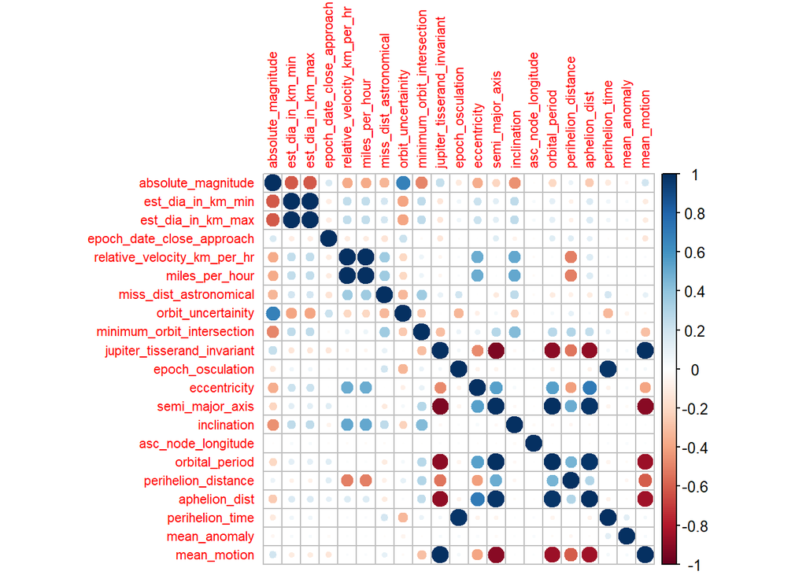

```r
pho_cor<-pho%>%
  select(-hazardous)%>%
  cor()%>%
  corrplot(tl.cex = 0.7)
```

From the graph, we see that some pairs of variables are strongly (positively or negatively) correlated such as minimum estimated diameter and maximum estimated diameter and we will just keep one of these pair variables.

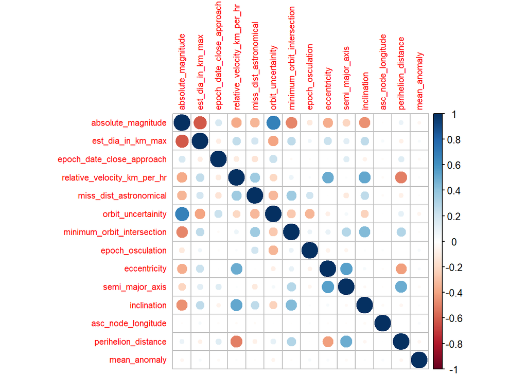

```r
pho_cor_new<-pho%>%
  select(-est_dia_in_km_min,-miles_per_hour,-jupiter_tisserand_invariant,-orbital_period,-aphelion_dist,-perihelion_time,-mean_motion,-hazardous)%>%
  cor() %>%
  corrplot(tl.cex = 0.7)
```

```r
pho<-pho%>%
  select(-est_dia_in_km_min,-miles_per_hour,-jupiter_tisserand_invariant,-orbital_period,-aphelion_dist,-perihelion_time,-mean_motion)
```

After we exclude these variables, our correlation plot looks much nicer and we now only have 15 variables to work with. We can then perform exploratory data analysis.

### Visual EDA

In this part, we are interested in the distribution of output variables and the distribution of some important predictors. Though we yet do not know which predictors are “important” to the response, we can still take a guess and focus on some of these variables. **If an asteroid were potentially hazardous to earth, it is likely that it would be very big (to survive passing through Earth’s atmosphere), close to the earth, and has high velocity. The measure of magnitude can be related to variables such as estimated maximum diameters.** Its closeness to earth is relevant to variables like inclination, minimum orbit intersection distance (“a measure used in astronomy to assess potential close approaches and collision risks between astronomical objects. It is defined as the distance between the closest points of the osculating orbits of two bodies.” -Wiki). Its velocity is already given in the dataset named relative velocity in kilometers per hour. The rest of the variables is connected to some properties of the orbit of any asteroid. I will provide a picture below to help my readers to understand. However, due to my limited understanding of the orbit, I am not sure how these variables can have some impact on the response variable, so I will not analyze them in this EDA. It is of course true that some of these variables greatly contribute to the response, but it is not easy for me to interpret why that is the case. Therefore, we will only consider some more interpretable variables in this EDA.

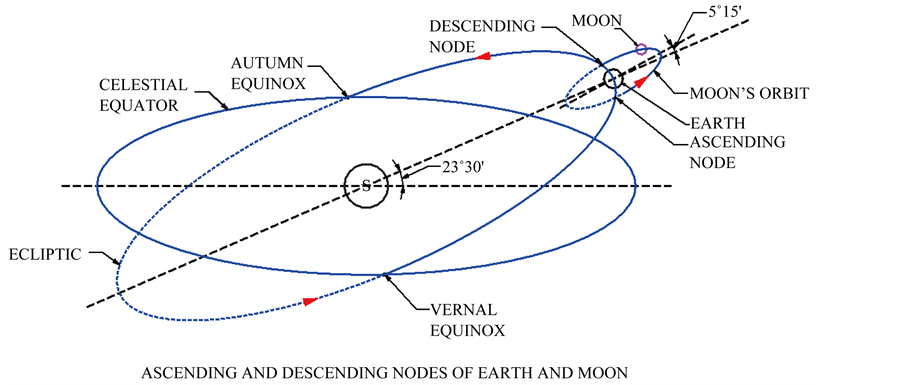

```r
knitr::include_graphics("C:/Users/lisha/Downloads/3.png")
```

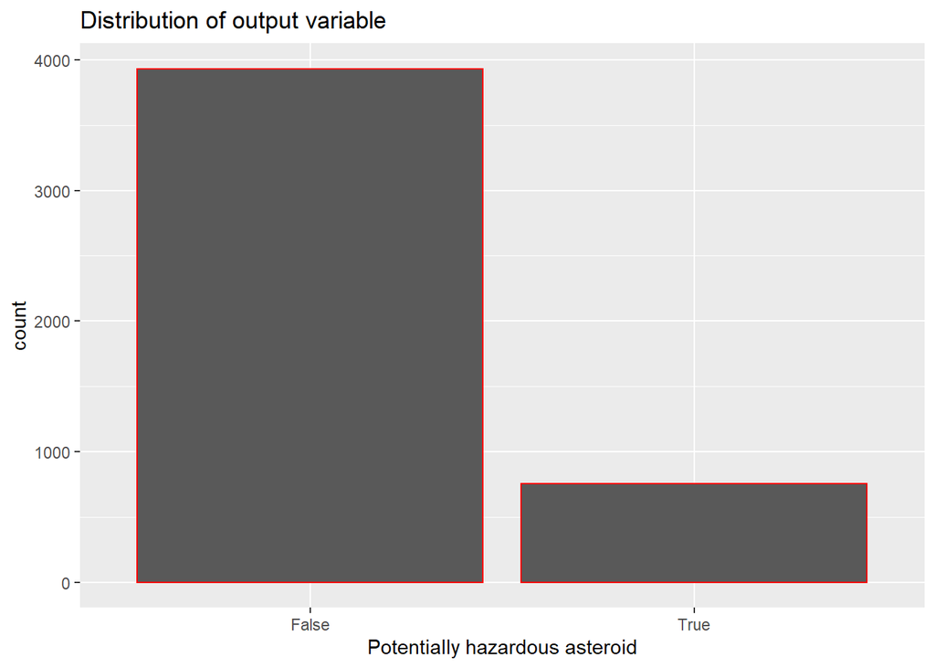

```r
ggplot(pho,aes(hazardous))+
  geom_bar(color="red")+
  labs(x="Potentially hazardous asteroid")+labs(title="Distribution of output variable")
```

It is now quite obvious that our output is imbalanced, meaning that when we do the modeling, **we need to stratify the output variable in order to achieve better results**. Moreover, this graph informs us that most of the asteroids are not hazardous to earth, so we do not need to worry about them. On the other hand, if there are some potentially hazardous asteroids, their impacts on earth can be huge. It is likely that some of them can cause dangerous tsunamis for example.

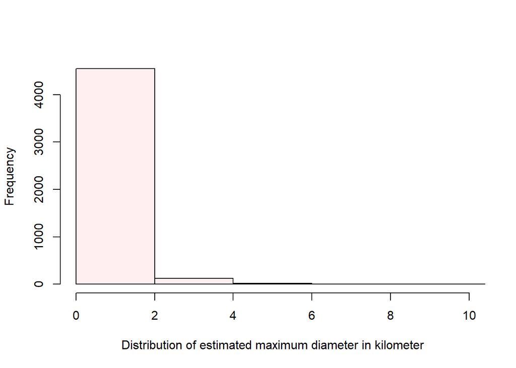

```r
hist(pho$est_dia_in_km_max,xlim = c(0,10),xlab="Distribution of estimated maximum diameter in kilometer",main="",col = "#ffeff1")
```

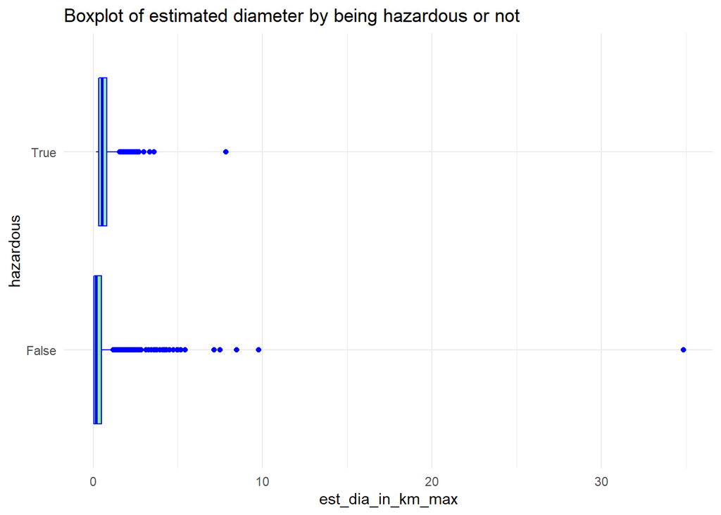

```r
ggplot(pho,aes(x=est_dia_in_km_max,y=hazardous))+geom_boxplot(color="blue",fill="lightgreen")+labs(
    title = "Boxplot of estimated diameter by being hazardous or not")+ theme_minimal()
```

Most of the asteroids have their estimated maximum diameter between 0 and 1, however, there are a few asteroids that have extremely large diameters. Indeed, if we check the maximum value of the estimated diameter, the maximum is 34.83694 kilometers, which is amazingly large. For comparison, the diameter of the earth is 12,756 km, much larger than any of these asteroids. The diameter of the moon is 3,500 km, still much larger than that of the asteroids. However, due to the effect of outliers, it is hard to see from the boxplot whether the estimated diameter has any relationship with being potentially hazardous or not.

[figure not shown]

```r
ggplot(pho,aes(x=minimum_orbit_intersection,group=factor(hazardous),fill=factor(hazardous)))+geom_histogram(color="aquamarine")+labs(title="Histogram of minimum orbit intersection")+scale_fill_discrete(labels=c('TRUE', 'FALSE')) + guides(fill=guide_legend(title="Hazardous")) + theme_minimal()
```

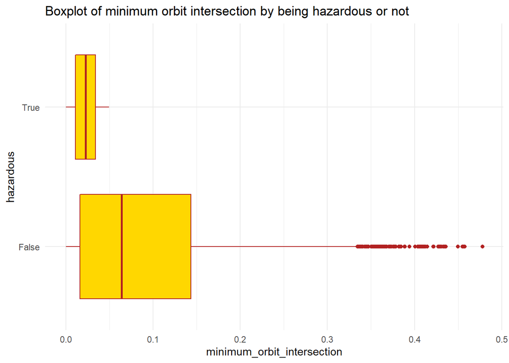

```r
ggplot(pho,aes(x=minimum_orbit_intersection,y=hazardous))+geom_boxplot(color="firebrick",fill="gold1")+labs(title = "Boxplot of minimum orbit intersection by being hazardous or not")+ theme_minimal()
```

Most of the orbit intersections are between 0 and 0.1. If this value is large, it means that the distance between the closest points of the osculating orbits of the asteroid and Earth is large and thus is less likely to have a collision. On the other hand, if this value is small, it is more likely that the collision would happen. This is indeed true because if we see the boxplot, **all the potentially hazardous asteroids have very small minimum orbit intersections**.

[figure not shown]

```r
ggplot(pho,aes(x=inclination,group=factor(hazardous),fill=factor(hazardous)))+geom_histogram(color="yellow")+labs(title="Histogram of inclination")+scale_fill_discrete(labels=c('TRUE', 'FALSE')) + guides(fill=guide_legend(title="Hazardous")) + theme_minimal()
```

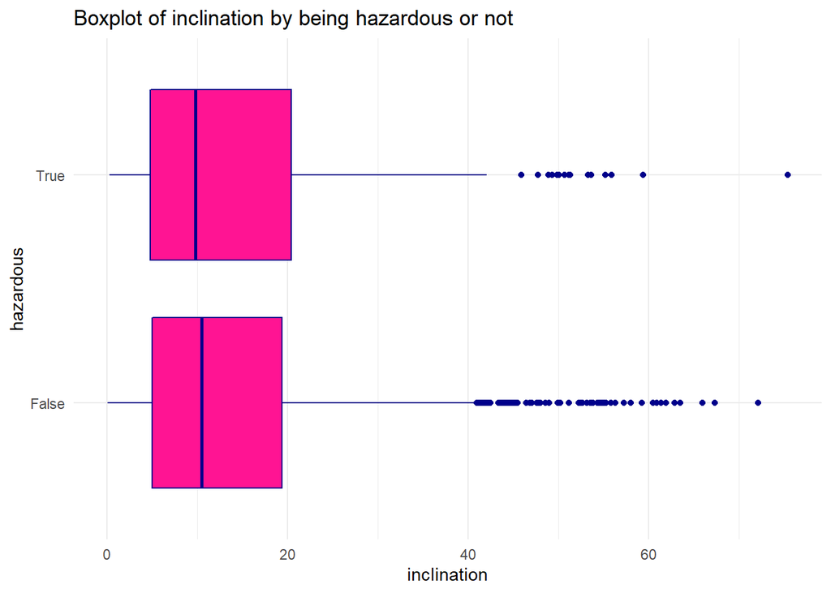

```r
ggplot(pho,aes(x=inclination,y=hazardous))+geom_boxplot(color="dark blue",fill="deeppink1")+labs(title = "Boxplot of inclination by being hazardous or not")+ theme_minimal()
```

Orbital inclination measures the tilt of an object’s orbit around a celestial body. It is expressed as the angle between a reference plane and the orbital plane or axis of direction of the orbiting object. Small inclination indicates these asteroids are more aligned with the plan of Earth’s orbit. Asteroids with lower-inclination orbits would be more likely to encounter Earth and easier to reach. From the graph, we can see that a great number of asteroids have lower-inclination (between 0 and 20 degrees). However, if we see the boxplot, because there are too many asteroids that have lower-inclination, the relationship between being potentially hazardous and inclination is unclear.

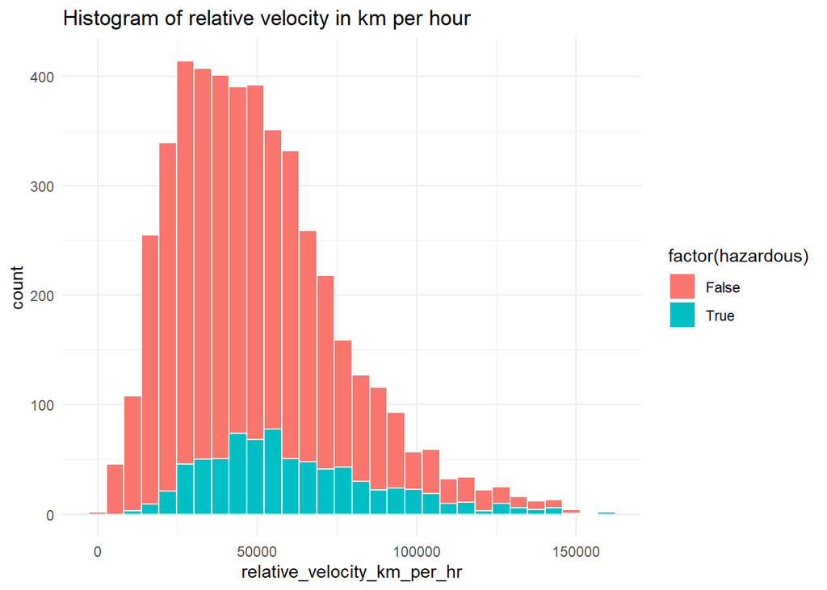

```r
ggplot(pho,aes(x=relative_velocity_km_per_hr,group=factor(hazardous),fill=factor(hazardous)))+geom_histogram(color="white")+labs(title="Histogram of relative velocity in km per hour")+theme_minimal()
```

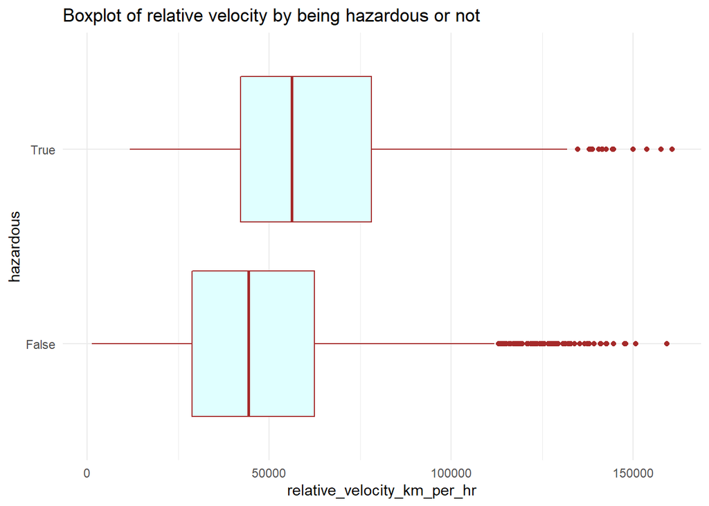

```r
ggplot(pho,aes(x=relative_velocity_km_per_hr,y=hazardous))+geom_boxplot(color=" brown",fill="lightcyan")+labs(title = "Boxplot of relative velocity by being hazardous or not")+theme_minimal()
```

The relative velocity is the speed that an asteroid travels in its orbit. Many asteroids in our dataset travel around the earth. From the histogram, we see that most of the asteroids have relative velocities between 25000 to 10000 kilometer per hour. For comparison, the moon orbits Earth at a speed of 3683 kilometers per hour. Thus, the speed of asteroids is actually much faster might due to their relatively small magnitude. It is clear from the boxplot that **those asteroids which are considered potentially hazardous have higher velocity**. This result verifies our initial guess.

# Setting Up Models

### Data Splitting

```r
pho$hazardous<-factor(pho$hazardous,levels=c("True","False")) # initially hazardous is considered as a character type, so we want to convert it to factor type
pho_split<-pho%>%
  initial_split(pro=0.7,strata = hazardous)
pho_train<-training(pho_split)
pho_test<-testing(pho_split)
dim(pho_train)
```

```
## [1] 3280   15
```

```r
dim(pho_test)
```

```
## [1] 1407   15
```

In our training set, we have in total 15 variables and 3280 observations. In our testing set, we have the same number of variables and 1407 observations. **We did the stratified sampling because our output variable is highly imbalanced, so this step is necessary**.

### Recipe Building

```r
pho_recipe <-recipe(
  hazardous~.,pho_train) %>%
  step_dummy(all_nominal_predictors())%>% # dummy predictor on categorical variables
  step_normalize() # this step is important because some of our variables are extremely small, while others are quite large.
```

### K-Fold Cross Validation

Since our data is not too large, five folds should be enough. Because we will model random forest, if the folds are too many, it will take a very long time. The basic idea of cross validation is illustrated below. **Though this approach can be computationally expensive, we do not waste any data, which is a major advantage when our sample size is small**.

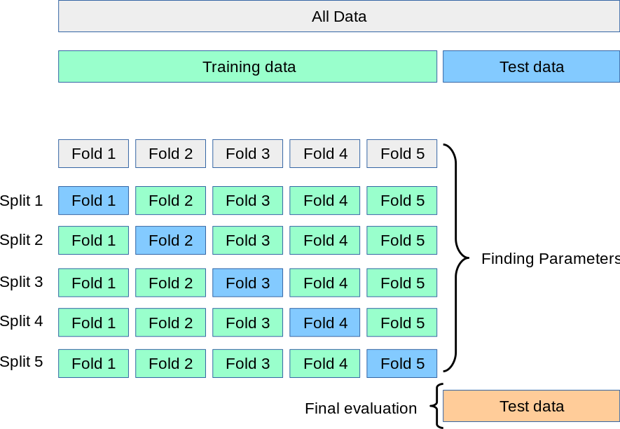

```r
knitr::include_graphics("C:/Users/lisha/Downloads/6.png")
```

```r
pho_folds<-vfold_cv(pho_train,v=5,strate=hazardous) # we stratify our data for the same reason
```

# Model Building

### Logistic Regression

Because logistic regression does not require any tuning, we simply fit the model and do cross-validation on the training set.

[figure not shown]

```r
knitr::include_graphics("C:/Users/lisha/Downloads/log.png")
```

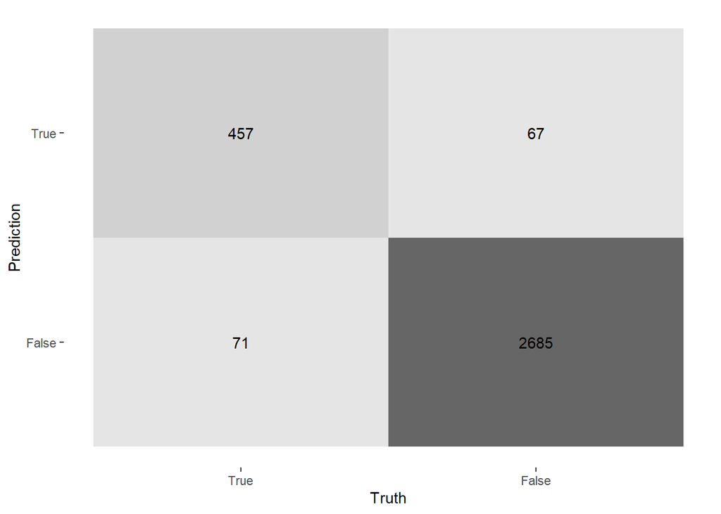

```r
log_reg <-logistic_reg() %>%
  set_engine("glm") %>%
  set_mode("classification")
log_wkflow<-workflow() %>%
  add_model(log_reg)%>%
  add_recipe(pho_recipe)
log_fit_res<-tune_grid(
  object=log_wkflow,
  resamples=pho_folds # for cross-validation
  )
log_fit<-fit(log_wkflow,pho_train)
augment(log_fit,new_data=pho_train) %>%
  conf_mat(truth=hazardous,estimate=.pred_class)%>%
  autoplot(type="heatmap")
```

```r
log_acc<-augment(log_fit,new_data=pho_train)%>%
  accuracy(truth=hazardous,estimate=.pred_class)
print(log_acc) # Accuracy is 0.9579
```

```
## # A tibble: 1 × 3
##   .metric  .estimator .estimate
##   <chr>    <chr>          <dbl>
## 1 accuracy binary         0.958
```

```r
log_precision<-augment(log_fit,pho_train)%>%
  precision(hazardous,.pred_class) # Precision is 0.872137
print(log_precision)
```

```
## # A tibble: 1 × 3
##   .metric   .estimator .estimate
##   <chr>     <chr>          <dbl>
## 1 precision binary         0.872
```

We see from the above that even the logistic regression does a good job of predicting whether an asteroid is hazardous or not. The accuracy is 0.9579, and the precision is 0.872137. Notice that since the output variable is greatly imbalanced, precision is actually a better metric than accuracy because a false negative does not give us too much information given the fact of the majority of the response is false. This performance, in general, shows that the response is not difficult to predict using the given predictors. We expect that all the following models to achieve even better performance.

### Quadratic Discriminant Analysis

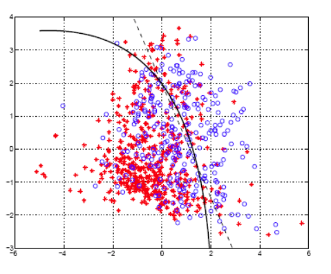

```r
knitr::include_graphics("C:/Users/lisha/Downloads/dis1.png")
```

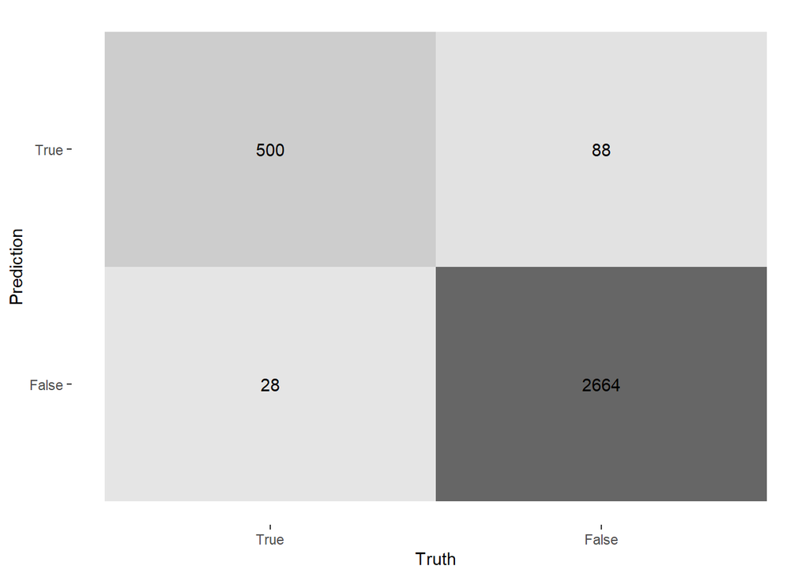

```r
library(MASS)
library(discrim) # for quadratic discriminant analysis
qda_mod<-discrim_quad()%>%
  set_mode("classification")%>%
  set_engine("MASS")
qda_wkflow<-workflow()%>%
  add_model(qda_mod)%>%
  add_recipe(pho_recipe)
qda_fit<-fit(qda_wkflow,pho_train)
augment(qda_fit,new_data=pho_train) %>%
  conf_mat(truth=hazardous,estimate=.pred_class)%>%
  autoplot(type="heatmap")
```

```r
qda_acc<-augment(qda_fit,new_data=pho_train)%>%
  accuracy(truth=hazardous,estimate=.pred_class)
print(qda_acc) # Accuracy is 0.9646341
```

```
## # A tibble: 1 × 3
##   .metric  .estimator .estimate
##   <chr>    <chr>          <dbl>
## 1 accuracy binary         0.965
```

```r
qda_precision<-augment(qda_fit,pho_train)%>%
  precision(hazardous,.pred_class) # Precision is 0.8503401
print(qda_precision)
```

```
## # A tibble: 1 × 3
##   .metric   .estimator .estimate
##   <chr>     <chr>          <dbl>
## 1 precision binary         0.850
```

This model performs similarly to logistic regression. We see a slight improvement in accuracy but the precision is lower. Honestly, both two models perform fairly well. However, since the precision of the two models is around 0.85, we can try to improve this to 0.9 or even higher using other models.

### Support Vector Machine

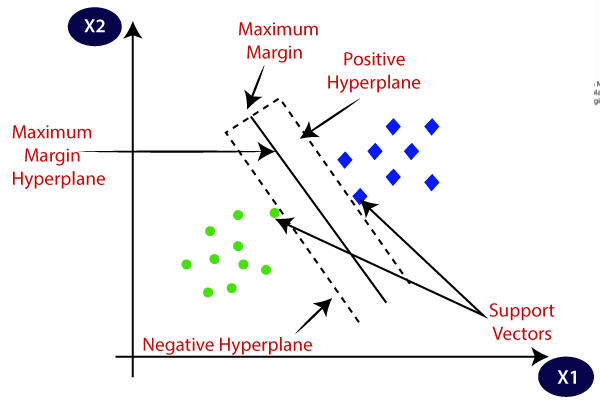

```r
knitr::include_graphics("C:/Users/lisha/Downloads/svm.png")
```

```r
library(kernlab)
svm_rbf_spec <- svm_rbf() %>%
  set_mode("classification") %>%
  set_engine("kernlab", scaled = FALSE)
svm_rbf_fit <- svm_rbf_spec %>%
  fit(hazardous ~ ., data=pho_train)
```

```
## maximum number of iterations reached 0.0004895261 -0.0004858422
```

```r
mtx<-augment(svm_rbf_fit, new_data = pho_train) %>%
  conf_mat(truth = hazardous, estimate = .pred_class)%>%
  autoplot(type="heatmap")
svm_acc<-augment(svm_rbf_fit,new_data=pho_train)%>%
  accuracy(truth=hazardous,estimate=.pred_class)
print(svm_acc) # Accuracy is 0.8390244
```

```
## # A tibble: 1 × 3
##   .metric  .estimator .estimate
##   <chr>    <chr>          <dbl>
## 1 accuracy binary         0.839
```

```r
svm_precision<-augment(svm_rbf_fit,pho_train)%>%
  precision(hazardous,.pred_class) # Precision is NA
print(svm_precision)
```

```
## # A tibble: 1 × 3
##   .metric   .estimator .estimate
##   <chr>     <chr>          <dbl>
## 1 precision binary            NA
```

First thing I want to clarify is that I did not use hyperparameter tuning for the reason that it was too time-consuming. Even if I set up the level to be 4, it was still running for 7 hours, and cannot finish plotting. I used hyperparameter tuning for all the following tree-based models, so I hope that is okay. Moreover, linear SVM did not perform well when I first tried, so I later changed to SVM with a radial basis function. Nevertheless, we can see that the result is still poor and the worst part is that we do not even have a precision value, as our true positive and false positive are both zero in SVM’s prediction. I was trying to think why this happened, and I googled to see how other people fitted the model. **It turns out that SVM performs poorly in imbalanced datasets and unfortunately my dataset is extremely imbalanced.** This is probably the reason why the positive and false positives are both zero, **as SVM cannot distinguish asteroids that are potentially hazardous from this highly imbalanced data**. I am actually surprised to find out that SVM did so bad given the fact that even logistic regression can have relatively high precision.

### Classification Tree Model

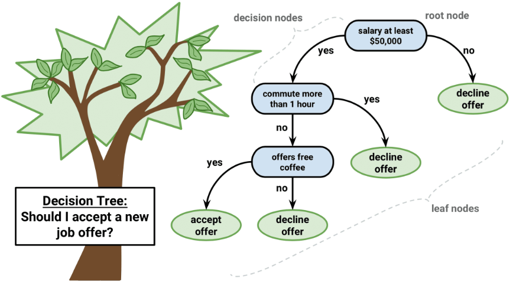

```r
knitr::include_graphics("C:/Users/lisha/Downloads/ct.png")
```

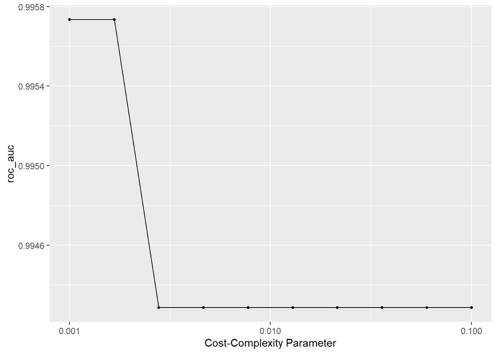

```r
pho_tree_spec <-decision_tree() %>%
  set_engine("rpart")
pho_class_tree_spec <- pho_tree_spec %>%
  set_mode("classification")
pho_class_tree_wkflow <- workflow() %>%
  add_model(pho_class_tree_spec %>% set_args(cost_complexity=tune())) %>% # for hyperparameter-tuning
  add_formula(hazardous~.)
pho_param_grid <-grid_regular(cost_complexity(range=c(-3,-1)),levels=10)
pho_class_tree_res <-tune_grid(
  pho_class_tree_wkflow,
  resamples=pho_folds,
  grid=pho_param_grid,
  metrics=metric_set(roc_auc)) # for cross-validation
autoplot(pho_class_tree_res)
```

```r
best_class_tree_complexity <-select_best(pho_class_tree_res)
collect_metrics(pho_class_tree_res) %>% arrange(-mean)
```

```
## # A tibble: 10 × 7
##    cost_complexity .metric .estimator  mean     n std_err .config
##              <dbl> <chr>   <chr>      <dbl> <int>   <dbl> <chr>
##  1         0.001   roc_auc binary     0.996     5 0.00175 Preprocessor1_Model01
##  2         0.00167 roc_auc binary     0.996     5 0.00175 Preprocessor1_Model02
##  3         0.00278 roc_auc binary     0.994     5 0.00148 Preprocessor1_Model03
##  4         0.00464 roc_auc binary     0.994     5 0.00148 Preprocessor1_Model04
##  5         0.00774 roc_auc binary     0.994     5 0.00148 Preprocessor1_Model05
##  6         0.0129  roc_auc binary     0.994     5 0.00148 Preprocessor1_Model06
##  7         0.0215  roc_auc binary     0.994     5 0.00148 Preprocessor1_Model07
##  8         0.0359  roc_auc binary     0.994     5 0.00148 Preprocessor1_Model08
##  9         0.0599  roc_auc binary     0.994     5 0.00148 Preprocessor1_Model09
## 10         0.1     roc_auc binary     0.994     5 0.00148 Preprocessor1_Model10
```

From the autoplot of cost complexity parameter, it seems to be the case that smaller cost complexity yields better result. The highest roc_auc is 0.9957344, which is amazingly good.

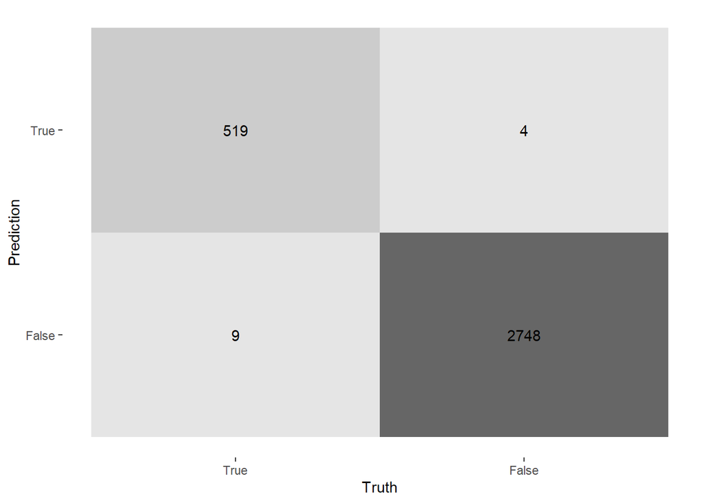

```r
class_tree_final<-finalize_workflow(pho_class_tree_wkflow,best_class_tree_complexity)
class_tree_final_fit<-fit(class_tree_final,data=pho_train)
augment(class_tree_final_fit,new_data=pho_train) %>%
  conf_mat(truth=hazardous,estimate=.pred_class)%>%
  autoplot(type="heatmap")
```

```r
class_tree_acc<-augment(class_tree_final_fit,new_data=pho_train)%>%
  accuracy(truth=hazardous,estimate=.pred_class)
print(class_tree_acc) # Accuracy is 0.9960366
```

```
## # A tibble: 1 × 3
##   .metric  .estimator .estimate
##   <chr>    <chr>          <dbl>
## 1 accuracy binary         0.996
```

```r
class_tree_precision<-augment(class_tree_final_fit,pho_train)%>%
  precision(hazardous,.pred_class) # Precision is 0.9923518
print(class_tree_precision)
```

```
## # A tibble: 1 × 3
##   .metric   .estimator .estimate
##   <chr>     <chr>          <dbl>
## 1 precision binary         0.992
```

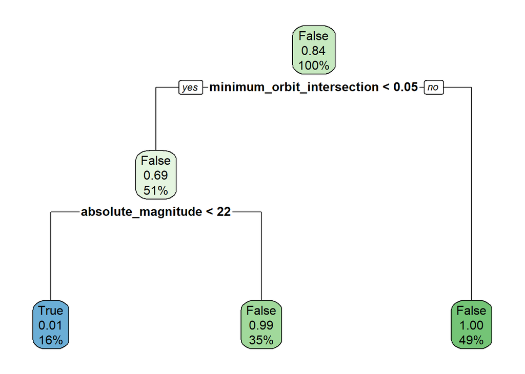

```r
class_tree_final_fit %>%
  extract_fit_engine()%>%
  rpart.plot()
```

Using classification model, we already had excellent result. After selecting the best cost complexity, our model now has accuracy 0.9960366, and precision 0.9923518. Compared to linear models such as logistic regression and quadratic discriminant analysis, we had huge improvement on both accuracy and precision. The improvement on precision is especially important because now we almost never misclassify true positive. The reason why we can have such outstanding performance is because, again, our response is relatively easy to predict using the given features, **which can be verified in our best-performing pruned decision tree**.

### Random Forest Model

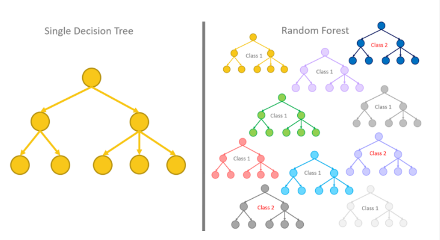

```r
knitr::include_graphics("C:/Users/lisha/Downloads/rf.png")
```

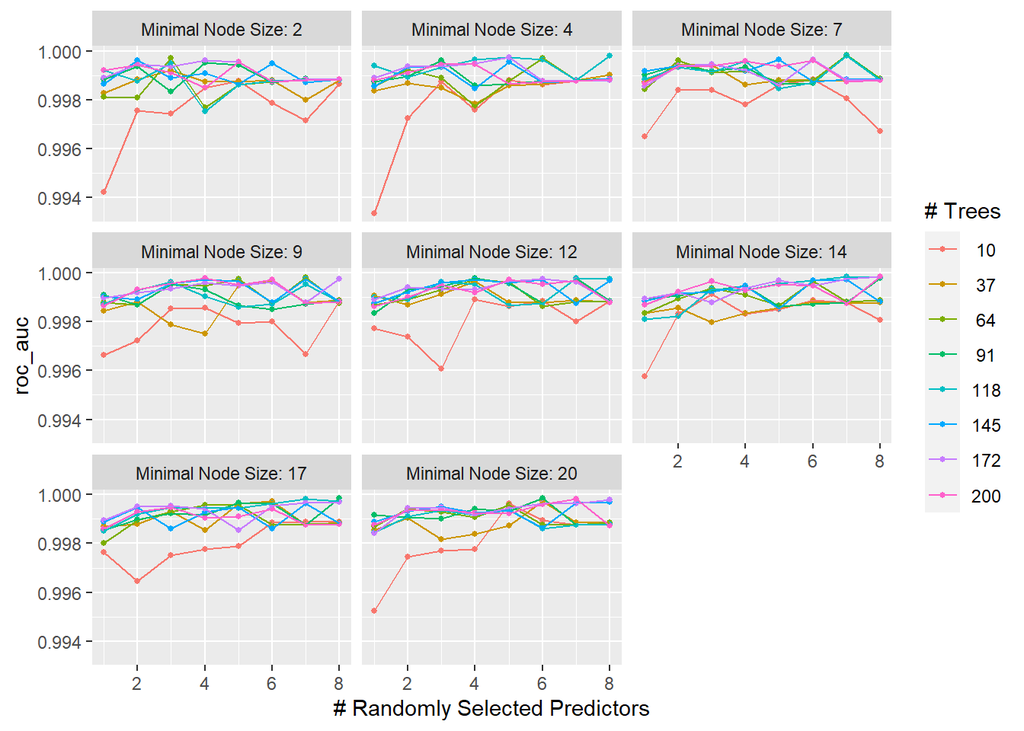

```r
pho_rf_spec<-rand_forest() %>%
  set_engine("ranger",importance="impurity")%>%
  set_mode("classification")
pho_rf_Wkflow<-workflow()%>%
  add_model(pho_rf_spec %>% set_args(mtry=tune(),trees=tune(),min_n=tune()))%>%
  add_formula(hazardous~.)
param_grid_rf<-grid_regular(mtry(range= c(1,8)),trees(range = c(10,200)),min_n(range = c(2,20)),levels = 8)
pho_res_rf <-tune_grid(
  pho_rf_Wkflow,
  resample=pho_folds,
  grid=param_grid_rf,
  metrics=metric_set(roc_auc)
)
autoplot(pho_res_rf)
```

Compared to the roc_auc plot in homework 6, this plot is quite different. The first thing I notice is that the number of randomly selected predictors does not have a crucial impact on the roc_auc. Though if only one predictor is selected, the roc_auc is generally the lowest. If, however, at least two predictors are selected, then it is hard to tell the difference of roc_auc. The minimal node size, similarly, does not yield a huge difference. However, it tends to be the case that when the minimal node size is relatively large, we see better roc_auc. Lastly, we check the influence of the number of trees.When the tree size is small, the roc_auc is noticeably lower in all the graphs. When the tree size is above 100, the difference of roc_auc is not substantial. **Among all the tree hyperparameters, the number of trees seems to be the most important factor that determines the performance**.

```r
library(vip)
collect_metrics(pho_res_rf) %>% arrange(-mean)
```

```
## # A tibble: 512 × 9
##     mtry trees min_n .metric .estimator  mean     n   std_err .config
##    <int> <int> <int> <chr>   <chr>      <dbl> <int>     <dbl> <chr>
##  1     6    91    20 roc_auc binary      1.00     5 0.0000733 Preprocessor1_Mod…
##  2     7   118    14 roc_auc binary      1.00     5 0.0000692 Preprocessor1_Mod…
##  3     8    91    17 roc_auc binary      1.00     5 0.0000861 Preprocessor1_Mod…
##  4     8   200    14 roc_auc binary      1.00     5 0.0000831 Preprocessor1_Mod…
##  5     8   172    14 roc_auc binary      1.00     5 0.0000769 Preprocessor1_Mod…
##  6     7   118    17 roc_auc binary      1.00     5 0.0000837 Preprocessor1_Mod…
##  7     7    64     7 roc_auc binary      1.00     5 0.0000820 Preprocessor1_Mod…
##  8     7    91     7 roc_auc binary      1.00     5 0.0000854 Preprocessor1_Mod…
##  9     7   200    20 roc_auc binary      1.00     5 0.0000979 Preprocessor1_Mod…
## 10     8   118     4 roc_auc binary      1.00     5 0.0000931 Preprocessor1_Mod…
## # … with 502 more rows
```